# 732A90: Computational Statistics

Computer lab6 - Group11

Sofie Jörgensen, Oriol Garrobé Guilera, David Hrabovszki

06 March 2020

# Question 1: Genetic algorithm

In this exercise we are going to perform one-dimensional maximization by using a genetic algorithm.

### 1.

Firstly, we define the function as

$$f(x):= \frac{x^2}{e^x} -2 \ \text{exp} (-(9\text{sin } x)/(x^2+x+1)).$$

### 2.

Secondly, we define the function , that takes two scalars $x$ and $y$ as inputs, and returns a child as $\frac{x+y}{2}$.

### 3.

Thirdly, we define the function , that performs the integer division $x^2 \text{ mod } 30$, for a scalar input $x$.

### 4.

(b). An initial population for the genetic algorithm is defined as $X = (0, 5, 10, 15,... ,30)$.

(c). A vector called are computed, containing the function values for each population point.

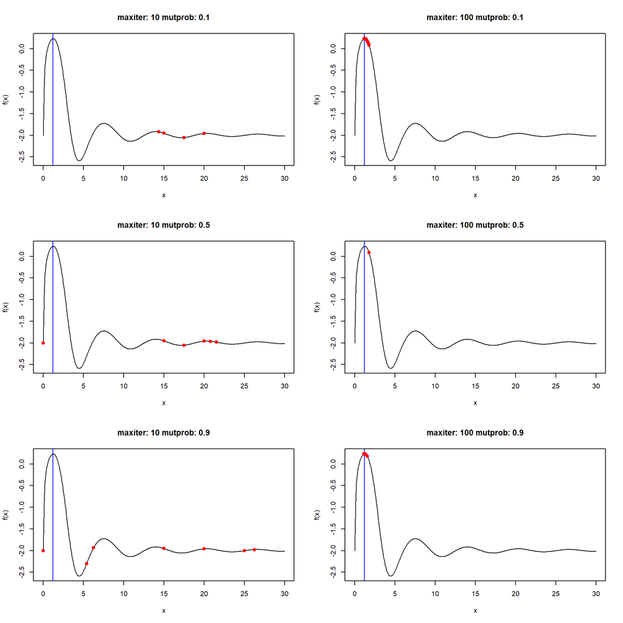

Genetic algorithm maximization

Maximum values

|  | maxiter 10 | maxiter 100 |
| --- | --- | --- |
| mutprob 0.1 | -1.922621 | 0.2315820 |
| mutprob 0.5 | -1.951947 | 0.0901318 |
| mutprob 0.9 | -1.937529 | 0.2348200 |

### 5.

By using the defined functions from previous tasks (1.1-1.4), we are going to observe the initial population and final population. This is done by running the code with different combinations of $= 10, 100$ and $= 0.1, 0.5, 0.9$.

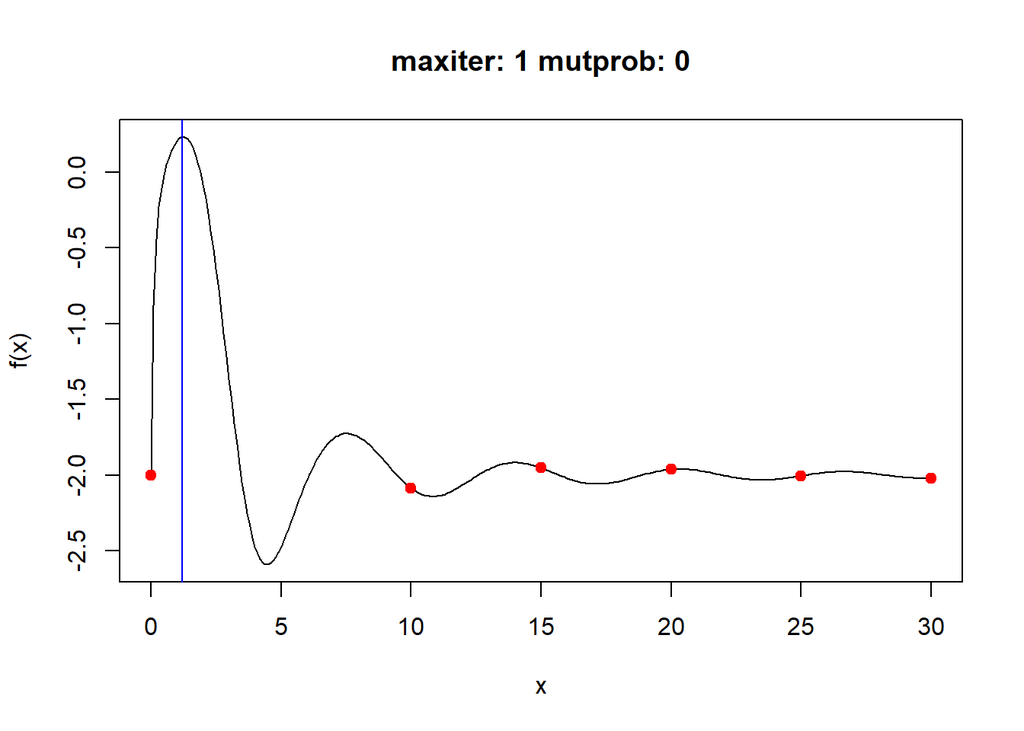

```
## [1] -1.951947
```

# Question 2: EM algorithm

The purpose with this exercise is to implement the EM algorithm. For this, we are given the data file , containing a behavior of two related physical processes $Y = Y(X)$ and $Z = Z(X)$.

### 1.

The first step is to examine the data set , to see if the two processes are related to each other.

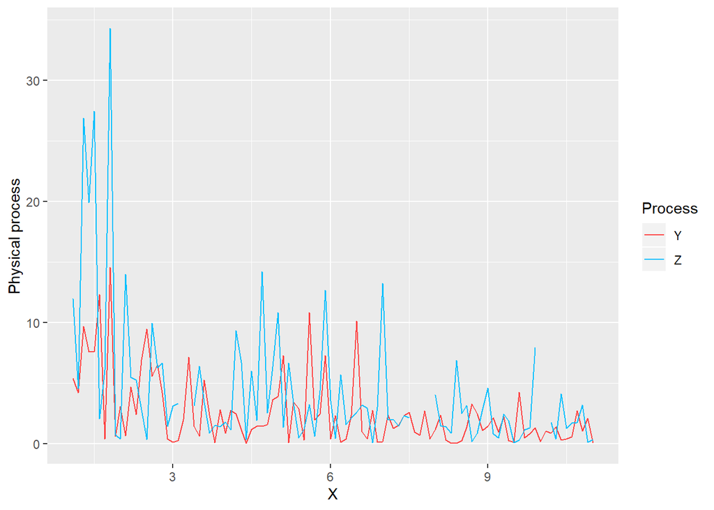

Time series plot of the dependence of Z and Y versus X.

In Figure it seems that the two processes are related to each other, with respect to $X$, since the graphs follows similar patterns. We can also observe that the physical process $Z$ has a greater variation, especially at the beginning of the series, but also in general, compared to the process $Y$.

### 2.

Using the following model,

$$\begin{eqnarray*}
Y_{i} \stackrel{}\sim exp\left(\frac{X_{i}}{\lambda}\right) \\
Z_{i} \stackrel{}\sim exp\left(\frac{X_{i}}{2\lambda}\right)
\end{eqnarray*}$$

where $\lambda$ is an unknown parameter, we derive the EM algorithm to estimate $\lambda$.

$Y$ and $Z$ are defined by the following density functions,
$$\begin{eqnarray*}
Z(X) &=& \frac{X_{i}}{2\lambda}exp\left(-\frac{X_{i}}{2\lambda}Z_{i}\right)\\
Y(X) &=& \frac{X_{i}}{\lambda}exp\left(-\frac{X_{i}}{\lambda}Y_{i}\right)
\end{eqnarray*}$$

Assuming that $Y(X)$ and $Z(X)$ are i.i.d. we can obtain the joint density function,
$$\begin{eqnarray*}
f(Y,Z) &=& \frac{X_{i}}{2\lambda}exp\left(-\frac{X_{i}}{2\lambda}Z_{i}\right) * \frac{X_{i}}{\lambda}exp\left(-\frac{X_{i}}{\lambda}Y_{i}\right)\\
&=& \frac{X^{2}_{i}}{2\lambda^{2}}
exp\left[-\frac{X_{i}(Z_{i}+2Y_{i})}{2\lambda}\right]
\end{eqnarray*}$$

From this point, we compute the likelihood of the distribution,

$$\begin{eqnarray*}
\mathcal{L}(Y,Z|X,\lambda) = \prod_{i=1}^{n}\frac{X^{2}_{i}}{2\lambda^{2}}exp\left[-\frac{X_{i}(Z_{i}+2Y_{i})}{2\lambda}\right]
\end{eqnarray*}$$

It is easier to work with the logarithm of the likelihood, therefore,
$$\begin{eqnarray*}
log\mathcal{L}(Y,Z|X,\lambda) &=& log\prod_{i=1}^{n}\frac{X^{2}_{i}}{2\lambda^{2}}exp\left[-\frac{X_{i}(Z_{i}+2Y_{i})}{2\lambda}\right] \\
&=& -nlog(2\lambda^{2}) + \sum^{n}_{i}log(X^{2}_{i}) - \sum^{n}_{i}\frac{X_{i}}{2\lambda}(Z_{i}+2Y_{i})
\end{eqnarray*}$$

**E-Step**
$$\begin{eqnarray*}
Q(\lambda,lambda^{k}) &=& E\left[log\mathcal{L}(Y,Z|X,\lambda)\right] \\
&=& -nlog(2\lambda^{2}) + \sum^{n}_{1}log(X^{2}_{i}) - \frac{1}{2\lambda}\sum^{r}_{1}X_{i}(Z_{i}+2Y_{i}) - \frac{1}{2\lambda}\sum^{n}_{r+1}X_{i}(E[Z_{i}]+2Y_{i}) \\
&=& -nlog(2\lambda^{2}) + \sum^{n}_{1}log(X^{2}_{i}) - \frac{1}{2\lambda}\sum^{r}_{1}X_{i}(Z_{i}+2Y_{i}) - \frac{1}{2\lambda}\sum^{n}_{r+1}X_{i}(\frac{2\lambda^{k}}{X_{i}}+2Y_{i}) \\
&=& -nlog(2\lambda^{2}) + \sum^{n}_{1}log(X^{2}_{i}) - \frac{1}{2\lambda}\sum^{r}_{1}X_{i}(Z_{i}+2Y_{i}) - \frac{1}{\lambda}\sum^{n}_{r+1}(\lambda^{k} + X_{i}Y_{i}) \\
\end{eqnarray*}$$

**M-Step**
$$\begin{eqnarray*}
\frac{\partial Q(\lambda,\lambda^{k})}{\partial\lambda} &=& 0 \\
\frac{\partial Q(\lambda,\lambda^{k})}{\partial\lambda} &=& -\frac{2n}{\lambda} + \frac{1}{2\lambda^{2}}\sum^{r}_{1}X_{i}(Z_{i}+2Y_{i}) + \frac{1}{\lambda^{2}}\sum^{n}_{r+1}(\lambda^{k} + X_{i}Y_{i})
\end{eqnarray*}$$

Therefore,
$$\begin{eqnarray*}
\lambda = \frac{\sum^{r}_{1}X_{i}(Z_{i}+2Y_{i}) + 2\sum^{n}_{r+1}(\lambda^{k} + X_{i}Y_{i})}{4n}
\end{eqnarray*}$$

The code can be found in the Appendix.

### 3.

Once we have the EM algorithm, we run it with initial value $\lambda_{0}=100$ and convergence criterion “stop if the change in $\lambda$ is less than 0.001”. This yields the following results.

```
## number_of_iterations       optimal_lambda
##              5.00000             10.69566
```

As we can see in only 5 iterations we reached the optimal $\lambda$.

### 4.

As a final task, we are going to see if the optimal value $\lambda= 10.69566$ is reasonable for the physical processes $Y = Y (X)$ and $Z = Z(X)$. We examine the results by computing the expected values of $Y$ and $Z$, which is given by $E[Y_i]=\frac{\lambda}{X_i}$ and $E[Z_i]=\frac{2\lambda}{X_i}$, respectively.

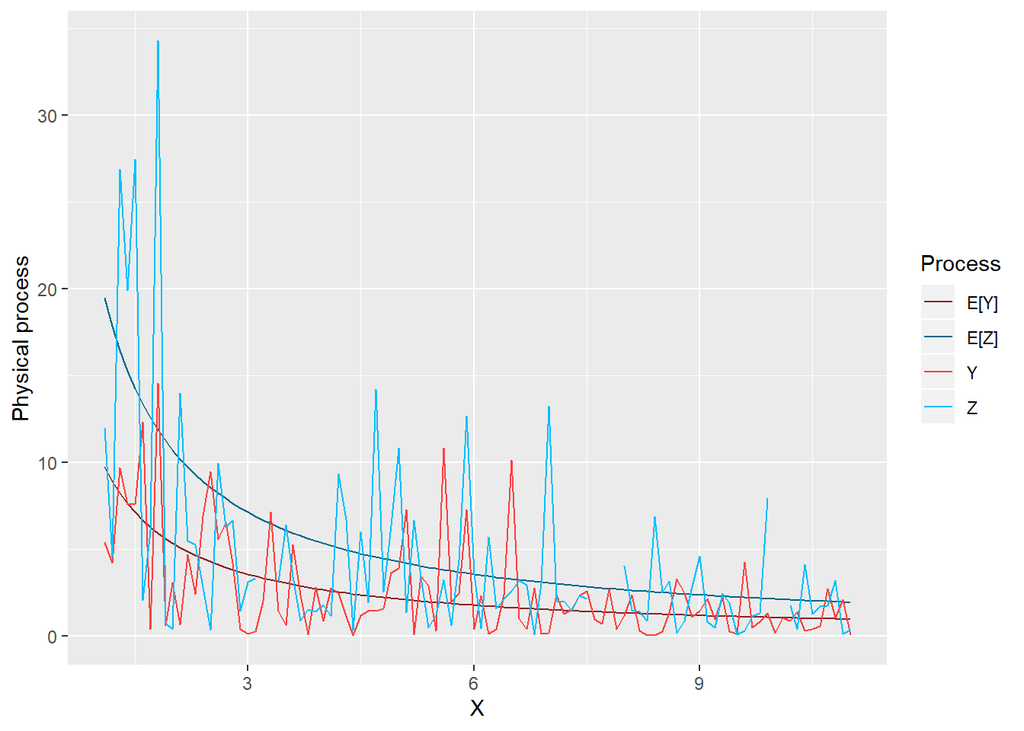

Time series plot of E[Y] and E[Z] versus X, and the dependence of Z and Y versus X.

In Figure , we can see that $E[Y]$ and $E[Z]$ versus $X$ are in the same plot as $Y$ and $Z$ versus $X$. From this plot it is clear that the optimal $\lambda$ is reasonable, since the exponential curves $E[Y]$ and $E[Z]$, the follow their corresponding values of $Y$ and $Z$.

# Appendix

```r
knitr::opts_chunk$set(echo = FALSE)
# R version
RNGversion('3.5.1')
library("ggplot2")
#1.1
f <- function(x){
  return(x^2/exp(x) - 2*exp(-1*(9*sin(x)) / (x^2 + x + 1)))
}

#1.2
crossover <- function(x,y){
  return((x+y) / 2)
}

#1.3
mutate <- function(x){
  return(x^2 %% 30)
}
#4
genetic <- function(maxiter, mutprob){
  #a
  plot(x = seq(0,30, by=0.1), y = f(seq(0,30, by=0.1)),
       type = "l", xlab = "x", ylab = "f(x)", main = paste("maxiter:",maxiter,"mutprob:",mutprob))
  abline(v=seq(0,30, by = 0.1)[which.max(f(seq(0,30,by = 0.1)))], col="blue" )
  #maximum value: f(1.2) = 0.234

  #b
  X = seq(0,30,5)

  #c
  Values = f(X)

  #d
  #set seed
  set.seed(1234567890)
  max=-Inf
  for (i in 1:maxiter) {
    #i
    parents = match(sample(X, 2),X)

    #ii
    victim = order(Values)[1]

    #iii
    kid = crossover(X[parents[1]],X[parents[2]])
    p = runif(1)
    if (p < mutprob) {
      kid = mutate(kid)
    }

    #iv
    X[victim] = kid
    Values = f(X)

    #v
    max = max(Values)
  }

  #e
  points(x = X, y = Values, col = "red", pch = 19)
  return(max)
}



max_values = data.frame(matrix(nrow = 3, ncol = 2))
par(mfrow=c(3,2))
max_values[1,1] = genetic(10,0.1)
max_values[1,2] = genetic(100,0.1)
max_values[2,1] = genetic(10,0.5)
max_values[2,2] = genetic(100,0.5)
max_values[3,1] = genetic(10,0.9)
max_values[3,2] = genetic(100,0.9)

rownames(max_values) = c("mutprob 0.1","mutprob 0.5","mutprob 0.9")
colnames(max_values) = c("maxiter 10","maxiter 100")
knitr::kable(max_values, caption = 'Maximum values')
# Just testing no change, i.e. initial population
genetic(1,0)
# 2.1
physical <- read.csv2("physical1.csv", sep = ",")

X <- as.numeric(as.character(physical$X))
Y <- as.numeric(as.character(physical$Y))
Z <- as.numeric(as.character(physical$Z))

data <- data.frame(X = c(X,X), value = c(Y,Z), Process= rep(c("Y","Z"), each= 100))

# var(Z,na.rm = TRUE)
# var(Y,na.rm = TRUE)

# Time series plot
ggplot(data = data, aes(x = X, y = value, col = Process)) +
  geom_line() +
  ylab("Physical process")+
  scale_color_manual(values=c( "brown1","deepskyblue1"))

## 2.2

EM_algorithm <- function(X, Y, Z, lambda, eps, k_max) {
    Z_obs <- Z[!is.na(Z)]
    Z_miss <- Z[is.na(Z)]

    X_obs <- X[!is.na(Z)]
    X_miss <- X[is.na(Z)]

    Y_obs <- Y[!is.na(Z)]
    Y_miss <- Y[is.na(Z)]

    n <- length(c(Z_obs, Z_miss))
    r <- length(Z_obs)

    k<-1
    lambda_prev <- lambda+10+100*eps #random number to initialize the algorithm
    lambda_curr <- lambda

    while (k<k_max+1 && abs(lambda_prev-lambda_curr)>=eps) {

        lambda_prev<-lambda_curr

        ## E-step
        EY <- -n*log(2*lambda_prev^2) + sum(log(X^2)) - sum(X_obs*(Z_obs+2*Y_obs))/(2*lambda_prev) - sum(lambda_curr+X_miss*Y_miss)/lambda_prev

        ## M-step
        lambda_curr <- (sum(X_obs*(Z_obs+2*Y_obs)) + 2*sum(lambda_curr+X_miss*Y_miss))/(4*n)

        k<-k+1

    }
    return(c(number_of_iterations = k-1, optimal_lambda = lambda_curr))
}

##2.3

EM_algorithm(X,Y,Z, 100, 0.001, 100)
# 2.4
optimal_lambda <- EM_algorithm(X,Y,Z, 100, 0.001, 100)[2]
# Expected values
EY <- optimal_lambda/X
EZ <- 2*optimal_lambda/X

data2 <- data.frame(X = c(X,X), value = c(Y,Z,EY,EZ), Process= rep(c("Y","Z","E[Y]","E[Z]"), each= 100))

#
ggplot(data = data2, aes(x = X, y = value, col = Process)) +
  geom_line() +
  ylab("Physical process") +
  scale_color_manual(values=c("brown4", "deepskyblue4", "brown1", "deepskyblue1"))
```